# homework-week-6

Natalie Robinson

October 21, 2017

# Homework 6

**1. Write a simple R function, z.prop.test() that can perform one- or two-sample Z-tests for proportion data**

```r
z.prop.test <- function(p1, n1, p2 = NULL, n2 = NULL, p0, alternative = "two.sided", conf.level = 0.95) {
  z <- z.test(x = p1, y = p2, alternative = "two.sided", mu = 0, sigma.x = NULL, sigma.y = NULL, conf.level = 0.95)
  if (n1*p1 > 5) {
    if (n1 * (1-p1) > 5)
      return(z, p.value, conf.int)
} else {
    print("Warning: do not assume normal distribution")
    return(z, p.value, conf.int)
  }
}

# this code is not correct, I need to work on this more
```

**Code for one sample Z test (from Module 10)**

one sample Z test:

pt <- prop.test(x = sum(v), n = length(v), p = 0.8, conf.level = 0.95, correct = FALSE, alternative = “less”) pt

two sample Z test:

pt <- prop.test(x = c(sum(v2), sum(v1)), n = c(length(v2), length(v1)), alternative = “two.sided”, correct = FALSE) pt

**2. The dataset from Kamilar and Cooper has in it a large number of variables related to life history and body size. For this exercise, the end aim is to fit a simple linear regression model to predict longevity (MaxLongevity_m) measured in months from species’ brain size (Brain_Size_Species_Mean) measured in grams. Do the following for both longevity~brain size and log(longevity)~log(brain size).**

```r
library(curl)
library(ggplot2)
f <- curl("https://github.com/fuzzyatelin/fuzzyatelin.github.io/raw/master/AN597_Fall17/KamilarAndCooperData.csv")
d <- read.csv(f, header = TRUE, sep = ",", stringsAsFactors = FALSE)
head(d)
```

```
##               Scientific_Name          Family          Genus      Species
## 1 Allenopithecus_nigroviridis Cercopithecidae Allenopithecus nigroviridis
## 2         Allocebus_trichotis Cercopithecidae      Allocebus    trichotis
## 3           Alouatta_belzebul        Atelidae       Alouatta     belzebul
## 4             Alouatta_caraya        Atelidae       Alouatta       caraya
## 5            Alouatta_guariba        Atelidae       Alouatta      guariba
## 6           Alouatta_palliata        Atelidae       Alouatta     palliata
##   Brain_Size_Species_Mean Brain_Size_Female_Mean   Brain_size_Ref
## 1                   58.02                  53.70 Isler et al 2008
## 2                      NA                     NA
## 3                   52.84                  51.19 Isler et al 2008
## 4                   52.63                  47.80 Isler et al 2008
## 5                   51.70                  49.08 Isler et al 2008
## 6                   49.88                  48.04 Isler et al 2008
##   Body_mass_male_mean Body_mass_female_mean Mass_Dimorphism
```

[output cut: 69 more lines]

**Fit the regression model and, using {ggplot2}, produce a scatterplot with the fitted line superimposed upon the data. Append the the fitted model equation to your plot (HINT: use the function geom_text()).**

```r
# standard plot

m1 <- lm(MaxLongevity_m ~ Brain_Size_Species_Mean, data = d)
m1
```

```
##
## Call:
## lm(formula = MaxLongevity_m ~ Brain_Size_Species_Mean, data = d)
##
## Coefficients:
##             (Intercept)  Brain_Size_Species_Mean
##                 248.952                    1.218
```

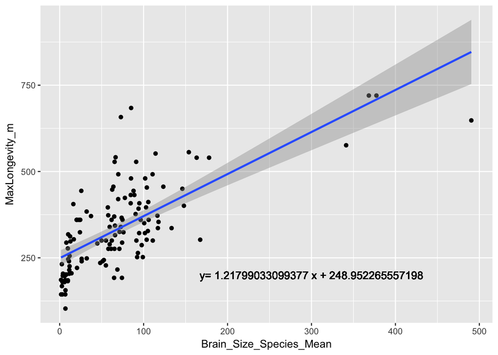

```r
slope <- m1$coefficients[2]
intercept <- m1$coefficients[1]
equation <- paste("y=", slope, "x", "+", intercept)

g <- ggplot(data = d, aes(x = Brain_Size_Species_Mean, y = MaxLongevity_m))
g <- g + geom_point()
g <- g + geom_smooth(method = "lm", formula = y ~ x)
g <- g + geom_text(aes(x = 300, y = 200, label = equation))
g
```

```r
# plot of log values

log_longevity <- log(d$MaxLongevity_m)
log_brain_size <- log(d$Brain_Size_Species_Mean)

new_data <- data.frame(log_longevity, log_brain_size)

m2 <- lm(log_longevity ~ log_brain_size, data = new_data)
m2
```

```
##
## Call:
## lm(formula = log_longevity ~ log_brain_size, data = new_data)
##
## Coefficients:
##    (Intercept)  log_brain_size
##         4.8790          0.2341
```

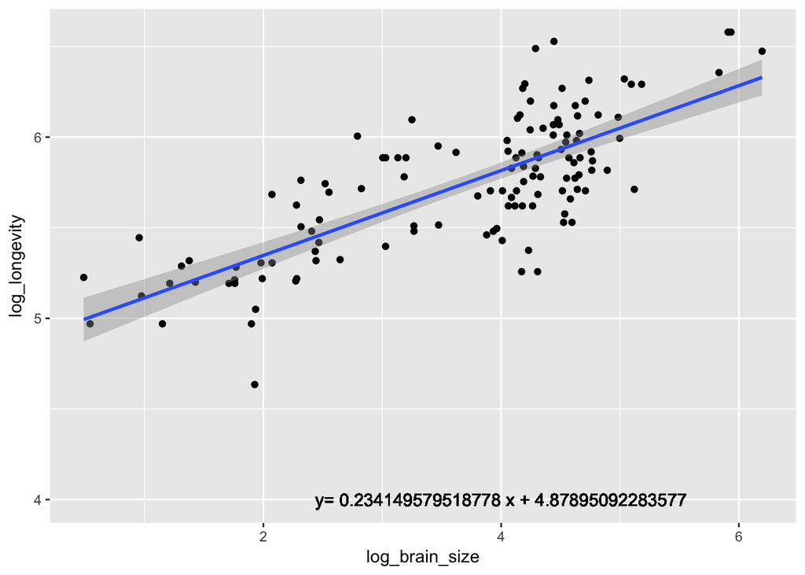

```r
slope2 <- m2$coefficients[2]
intercept2 <- m2$coefficients[1]
equation2 <- paste("y=", slope2, "x", "+", intercept2)

g <- ggplot(data = new_data, aes(x = log_brain_size, y = log_longevity))
g <- g + geom_point()
g <- g + geom_smooth(method = "lm", formula = y ~ x)
g <- g + geom_text(aes(x = 4, y = 4, label = equation2))
g
```

**Identify and interpret the point estimate of the slope (β1), as well as the outcome of the test associated with the hypotheses H0: β1 = 0; HA: β1 ≠ 0. Also, find a 90 percent CI for the slope (β1) parameter.**

*for the standard plot: the slope is 1.218* for the log plot: the slope is 0.2341

*Both slopes are positive, meaning that as brain size increases, longevity also increases.* The slopes are not equal to 0, so the null hypothesis should be rejected. We should accept the alternative hypothesis.

```r
# confidence interval for standard plot
ci1 <- confint(m1, level = 0.90)
ci1
```

```
##                                5 %      95 %
## (Intercept)             230.540738 267.36379
## Brain_Size_Species_Mean   1.035571   1.40041
```

```r
# confidence interval for log plot
ci2 <- confint(m2, level = 0.90)
ci2
```

```
##                      5 %      95 %
## (Intercept)    4.7644934 4.9934084
## log_brain_size 0.2046396 0.2636595
```

**Using your model, add lines for the 90 percent confidence and prediction interval bands on the plot and add a legend to differentiate between the lines.**

```r
# standard plot
# this should be similar to challenge in module 12

v = seq(from = 0, to = 500, by = 1)
m1 <- lm(MaxLongevity_m ~ Brain_Size_Species_Mean, data = d)
ci <- predict(m1, newdata = data.frame(Brain_Size_Species_Mean = v), interval = "confidence", level = 0.90)
pi <- predict(m1, newdata = data.frame(Brain_Size_Species_Mean = v), interval = "prediction", level = 0.90)

df <- data.frame(cbind(v, ci, pi))
names(df) <- c("Brain_Size_Species_Mean", "CIfit", "CIlwr", "CIupr", "PIfit", "PIlwr", "PIupr")
head(df)

slope <- m1$coefficients[2]
intercept <- m1$coefficients[1]
equation <- paste("y=", slope, "x", "+", intercept)

g <- ggplot(data = d, aes(x = Brain_Size_Species_Mean, y = MaxLongevity_m))
g <- g + geom_point()
g <- g + geom_line(data = df, aes(x = v, y = CIfit), colour = "black", lwd = 1)
g <- g + geom_line(data = df, aes(x = v, y = CIlwr), colour = "blue")
g <- g + geom_line(data = df, aes(x = v, y = CIupr), colour = "blue")
g <- g + geom_line(data = df, aes(x = v, y = PIlwr), colour = "red")
g <- g + geom_line(data = df, aes(x = v, y = PIupr), colour = "red")
g <- g + geom_text(aes(x = 300, y = 200, label = equation))
g <- g + geom_text(aes(x = 300, y = 150, label = "blue = CI, red = PI"))
g
```

[output not shown]

Legend: blue = CI, red = PI

```r
# log plot

v2 = seq(from = 0, to = 7, by = 1)
m2 <- lm(log(MaxLongevity_m) ~ log(Brain_Size_Species_Mean), data = d)
ci2 <- predict(m2, newdata = data.frame(Brain_Size_Species_Mean = v2), interval = "confidence", level = 0.90)
pi2 <- predict(m2, newdata = data.frame(Brain_Size_Species_Mean = v2), interval = "prediction", level = 0.90)

df2 <- data.frame(cbind(v2, ci2, pi2))
names(df2) <- c("Brain_Size_Species_Mean", "CIfit2", "CIlwr2", "CIupr2", "PIfit2", "PIlwr2", "PIupr2")
head(df2)
```

```
##   Brain_Size_Species_Mean   CIfit2   CIlwr2   CIupr2   PIfit2   PIlwr2
## 1                       0     -Inf      NaN      NaN     -Inf      NaN
## 2                       1 4.878951 4.764493 4.993408 4.878951 4.451636
## 3                       2 5.041251 4.945965 5.136537 5.041251 4.618668
## 4                       3 5.136191 5.051839 5.220542 5.136191 4.715938
## 5                       4 5.203551 5.126771 5.280331 5.203551 4.784752
## 6                       5 5.255800 5.184750 5.326851 5.255800 4.838014
##     PIupr2
## 1      NaN
## 2 5.306266
## 3 5.463834
## 4 5.556443
## 5 5.622350
## 6 5.673586
```

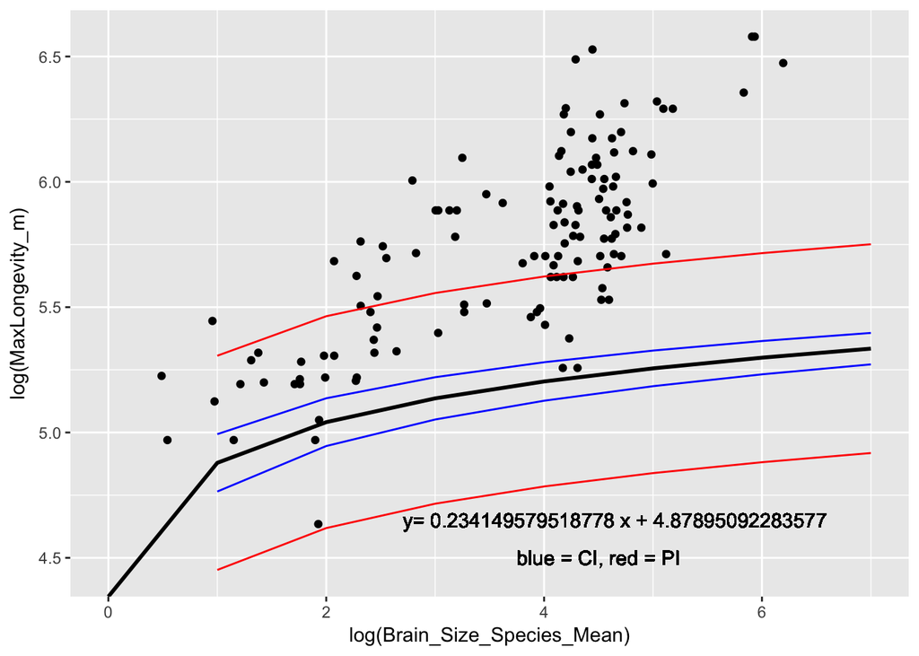

```r
slope2 <- m2$coefficients[2]
intercept2 <- m2$coefficients[1]
equation2 <- paste("y=", slope2, "x", "+", intercept2)

g <- ggplot(data = d, aes(x = log(Brain_Size_Species_Mean), y = log(MaxLongevity_m)))
g <- g + geom_point()
g <- g + geom_line(data = df2, aes(x = v2, y = CIfit2), colour = "black", lwd = 1)
g <- g + geom_line(data = df2, aes(x = v2, y = CIlwr2), colour = "blue")
g <- g + geom_line(data = df2, aes(x = v2, y = CIupr2), colour = "blue")
g <- g + geom_line(data = df2, aes(x = v2, y = PIlwr2), colour = "red")
g <- g + geom_line(data = df2, aes(x = v2, y = PIupr2), colour = "red")
g <- g + geom_text(aes(x = 4.65, y = 4.65, label = equation2))
g <- g + geom_text(aes(x = 4.5, y = 4.5, label = "blue = CI, red = PI"))
g
```

```r
# why does this look so weird? Should x min be > 0?
```

**Produce a point estimate and associated 90 percent PI for the longevity of a species whose brain weight is 800 gm. Do you trust the model to predict observations accurately for this value of the explanatory variable? Why or why not?**

```r
# standard

pi <- predict(m1, data.frame(Brain_Size_Species_Mean = 800), interval = "prediction", level = 0.90)
pi
```

```
##        fit      lwr      upr
## 1 1223.345 1021.805 1424.884
```

```r
# log

pi2 <- predict(m2, data.frame(Brain_Size_Species_Mean = 800), interval = "prediction", level = 0.90)
pi2
```

```
##       fit      lwr      upr
## 1 6.44415 6.021424 6.866876
```

The method used in lm() defaults to ordinary least squares, which creates an equation to tell us how Y varies in response to changes in X. The regression model predicts longevity from brain size. However, I don’t think this is the best possible model. Brain size could vary based on longevity, or they could covary. Using other models such as RMA, SMA, or MA could create better predictions.

**Looking at your two models, which do you think is better? Why?**

I think the log model is better. Graphically, it is easier to look at. The scale of the axes is smaller, and it is easier to see each data point. However, a downside of taking the log of each value is that it makes less sense logically. What does the log of brain size, for example, really tell you?